# Project memo

Brynn Sasha & Yuka

## Loading Packages

```r
library(tidyverse)
library(broom)

#used for plot 1
library(lubridate)
library(scales)

#used for plot 2
library(dplyr)
library(tidyr)
library(ggplot2)
library(maps)
library(scatterpie)
library(stringr)

#used for plot 3
library(forcats)

ai_data <- read_csv("../data/Charlotin-hallucination_cases.csv")
#view(ai_data)
```

## Data Clean Up Steps for Overall Data

##### Step 1:

First, we renamed the variables in the dataset.

```r
ai_data <- as_tibble(ai_data) |>
  rename(
`case_name` = `Case Name`,
`court_location` = `Court`,
`country` = `State(s)`,
`date` = `Date`,
`party` = `Party(ies)`,
`ai_tool` = `AI Tool`,
`hallucination` = `Hallucination`,
`outcome` = `Outcome`,
`monetary_penalty` = `Monetary Penalty`,
`professional_sanction` = `Professional Sanction`,
`key_principle` = `Key Principle`,
`pointer` = `Pointer`,
`source` = `Source`,
`details` = `Details`
)
```

##### Step 2:

Next, we did some general cleanup for six of our variables by removing extra spaces, capitalizing each word, and converting all empty cells to N/A.

```r
ai_data <- ai_data |>
  mutate(
    across(
      c(court_location, country, hallucination, outcome, monetary_penalty, professional_sanction),
      ~ .x |> str_squish() |> str_to_title() |> na_if("")
    )
  )
```

##### Step 3:

Although we did not end up using the monetary penalty variable for our final plots, we cleaned it up by first establishing the currency exchange rates, then converting everything to lowercase and making empty cells NA. Finally, we converted all amounts into USD using the exchange rate table, and replaced all original values with the USD conversion.

```r
rates <- tibble::tribble(
  ~currency, ~rate_to_usd,
  "USD", 1,
  "EUR", 1.07,
  "Gbp", 1.24,
  "Cad", 0.73,
  "Ils", 0.31,
  "Aud", 0.66
)


monetary_penalty_clean <- ai_data |>
  mutate(
    monetary_penalty_clean = monetary_penalty |>
      str_replace_all("[$,]", "") |>
      str_squish(),
    monetary_penalty_clean = na_if(str_to_lower(monetary_penalty_clean), "none"),
    monetary_penalty_clean = na_if(monetary_penalty_clean, "n/a"),
    monetary_penalty_clean = na_if(monetary_penalty_clean, "na"),
    monetary_penalty_clean = na_if(monetary_penalty_clean, "N/A"),
    currency = str_extract(
      str_to_lower(monetary_penalty_clean),
      "(usd|cad|ils|eur|gbp|aud)"
    ),
    currency = str_to_upper(currency),
    monetary_amount = readr::parse_number(monetary_penalty_clean),
    currency = if_else(is.na(currency) & !is.na(monetary_amount),
                       "USD", currency)
  ) |>
  left_join(rates, by = "currency") |>
  mutate(
    monetary_penalty_usd = monetary_amount * rate_to_usd,
    currency = if_else(!is.na(monetary_amount), "USD", NA_character_)
  )
```

##### Step 4:

Finally, we cleaned the professional sanction variable. We also did not use this variable in our final plots, but the cleanup consisted of standardizing all variations of yes/y and no/n to be “Yes” and “No” for readability.

```r
ai_data <- ai_data |>
  mutate(
    professional_sanction = case_when(
      str_detect(professional_sanction, regex("yes|y", ignore_case = TRUE)) ~ "Yes",
      str_detect(professional_sanction, regex("no|n", ignore_case = TRUE)) ~ "No",
      TRUE ~ professional_sanction
    )
  )
```

## Plots

### Plot 1: Trend of AI Hallucination Cases by Most Used LLM (2023-2025)

#### Plot 1 Data Cleanup

##### Step 1:

First, we cleaned the AI tool variable. To do this, we got rid of extra spaces and punctuation, converted all text to lowercase, and made all empty cells NA. Then, we made a list of synonyms for all of the most frequently used LLM’s, and finally used the mutate() command to replace all variations of each AI tool spelling with a standardized version.

```r
ai_tool_tidy <- ai_data |>
  mutate(ai_tool = str_replace_all(ai_tool, " and | & ", ",")) |>
  separate_rows(ai_tool, sep = ",|/|;") |>
  mutate(ai_tool = str_squish(ai_tool),
         ai_tool = na_if(ai_tool, ""),
         ai_tool = if_else(str_to_lower(ai_tool) %in% c("n/a","na","none"), NA_character_, ai_tool)) |>
  drop_na(ai_tool)

synonyms <- c(
  "ChatGPT" = "OpenAI ChatGPT",
  "GPT-4" = "OpenAI ChatGPT",
  "GPT4" = "OpenAI ChatGPT",
  "Google Gemini" = "Gemini",
  "Google Bard" = "Gemini",
  "Bard" = "Gemini",
  "Claude" = "Anthropic Claude",
  "implied" = "Implied",
  "Copilot" = "MS Copilot",
  "Microsoft CoPilot" = "MS Copilot",
  "CoPilot" = "MS Copilot"
)
ai_tool_tidy <- ai_tool_tidy |>
  mutate(ai_tool = coalesce(synonyms[ai_tool], ai_tool))
```

##### Step 2:

Next, we found and ranked the amount of hallucination cases for each type of LLM each month. Our first chunk of code converts each date to a real date object and extracts the first day of that month. Next, we identified which LLM was used, then counted the number of cases for each tool each month. Finally, we computed the LLM with the largest monthly value and ordered them from largest to smallest.

```r
monthly_tools <- ai_data |>
  mutate(
    date  = ymd(date),
    month = floor_date(date, "month")
  ) |>
  filter(!is.na(`ai_tool`)) |>
  mutate(
    tool = case_when(
      str_detect(`ai_tool`, regex("chatgpt", ignore_case = TRUE)) ~ "OpenAI ChatGPT",
      str_detect(`ai_tool`, regex("copilot", ignore_case = TRUE)) ~ "MS Copilot",
      str_detect(`ai_tool`, regex("gemini|bard", ignore_case = TRUE)) ~ "Gemini",
      TRUE ~ NA_character_
    )
  ) |>
  filter(!is.na(tool)) |>
  count(month, tool, name = "n")

tool_order <- monthly_tools |>
  group_by(tool) |>
  summarise(total = sum(n), .groups = "drop") |>
  arrange(desc(total)) |>
  pull(tool)

monthly_tools <- monthly_tools |>
  mutate(tool = factor(tool, levels = tool_order))

max_cases <- max(monthly_tools$n, na.rm = TRUE)
```

### Final Plot 1

We aimed to analyze monthly trends in hallucination cases by comparing occurrences across different LLM tools. To ensure consistency, we formatted all dates as year-month-day and grouped cases by month. We filtered for rows with entries in the ‘ai_tool’ column. Using case_when(), we standardized tool names (ChatGPT, MS CoPilot, Gemini) regardless of synonyms or capitalization. We focused analysis on the top three LLMs based on reported cases. For clarity in the legend, we listed LLMs in descending order of total cases by grouping and counting entries. We adjusted the y-axis to fit the maximum number of cases found, using the max_cases variable for customization. To avoid overcrowding the x-axis, we displayed axis breaks every 6 months instead of every month. Finally, we chose the “Dark2” palette from RColorBrewer for accessibility.

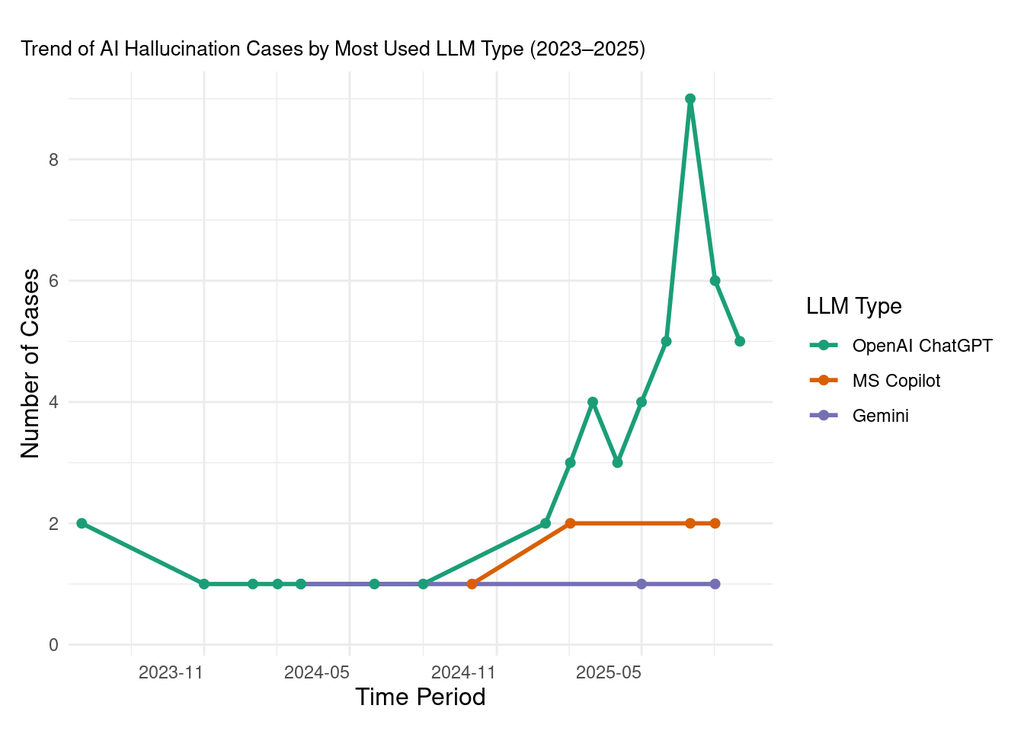

```r
ggplot(monthly_tools,
       aes(x = month, y = n, colour = tool, group = tool)) +
  geom_line(linewidth = 1) +
  geom_point(size = 1.8) +
  scale_x_date(
    date_breaks = "6 months",
    date_labels = "%Y-%m",
    expand = expansion(mult = c(0.02, 0.05))
  ) +
  scale_y_continuous(
    breaks = seq(0, max_cases, by = 2),
    limits = c(0, max_cases),
    expand = expansion(mult = c(0.02, 0.05))
  ) +
  scale_colour_brewer(palette = "Dark2", name = "LLM Type") +
  labs(
    title = "Trend of AI Hallucination Cases by Most Used LLM Type (2023–2025)",
    x = "Time Period",
    y = "Number of Cases"
  ) +
  theme_minimal() +
  theme(
    plot.title.position = "plot",
    plot.title = element_text(size = 10, hjust = 0),
    plot.margin = margin(t = 20, r = 10, b = 10, l = 10),
    axis.text.x = element_text(hjust = 1),
    axis.title.x = element_text(size = 12),
    axis.title.y = element_text(size = 12)
  )
```

```r
ggsave("trendbyLLM.png", width = 6, height = 4, units = "in")
```

### Plot 2: AI Hallucination Cases and Corresponding Outcome by State

#### Plot 2 Data Cleanup

##### Step 1:

First, we standardized the court locations across the dataset. Our code uses the case_when() command to look through each court location and check it against a series of synonyms and alternative spellings/abbreviations used to refer to different states. When a match is found, the text is replaced with our standardized state name. All international courts were changed to “International,” since the purpose of this step was to clean up the variable to use in our US state pie map.

```r
ai_data <- ai_data |>
  mutate(
    court_location = case_when(
      str_detect(court_location, regex("Iowa", ignore_case = TRUE)) ~ "Iowa",
      str_detect(court_location, regex("Alabama", ignore_case = TRUE)) ~ "Alabama",
      str_detect(court_location, regex("Arizona", ignore_case = TRUE)) ~ "Arizona",
      str_detect(court_location, regex("Arkansas", ignore_case = TRUE)) ~ "Arkansas",
      str_detect(court_location, regex("California|Fifth|Cal.|3rd|Cal|2nd|9th", ignore_case = TRUE)) ~ "California",
      str_detect(court_location, regex("Colorado", ignore_case = TRUE)) ~ "Colorado",
      str_detect(court_location, regex("Connecticut", ignore_case = TRUE)) ~ "Connecticut",
      str_detect(court_location, regex("Florida", ignore_case = TRUE)) ~ "Florida",
      str_detect(court_location, regex("Georgia|Ga.", ignore_case = TRUE)) ~ "Georgia",
      str_detect(court_location, regex("Hawaii|Hawai'i", ignore_case = TRUE)) ~ "Hawaii",
      str_detect(court_location, regex("Idaho", ignore_case = TRUE)) ~ "Idaho",
      str_detect(court_location, regex("Illinois|Cook County|7th", ignore_case = TRUE)) ~ "Illinois",
      str_detect(court_location, regex("Indiana|Ind.", ignore_case = TRUE)) ~ "Indiana",
      str_detect(court_location, regex("Kansas", ignore_case = TRUE)) ~ "Kansas",
      str_detect(court_location, regex("Kentucky", ignore_case = TRUE)) ~ "Kentucky",
      str_detect(court_location, regex("Louisiana", ignore_case = TRUE)) ~ "Louisiana",
      str_detect(court_location, regex("Maine", ignore_case = TRUE)) ~ "Maine",
      str_detect(court_location, regex("Maryland", ignore_case = TRUE)) ~ "Maryland",
      str_detect(court_location, regex("Massachusetts", ignore_case = TRUE)) ~ "Massachusetts",
      str_detect(court_location, regex("Michigan|Mich.", ignore_case = TRUE)) ~ "Michigan",
      str_detect(court_location, regex("Minnesota|Minnesotta", ignore_case = TRUE)) ~ "Minnesota",
      str_detect(court_location, regex("Mississippi|Miss.", ignore_case = TRUE)) ~ "Mississippi",
      str_detect(court_location, regex("Missouri", ignore_case = TRUE)) ~ "Missouri",
      str_detect(court_location, regex("Montana", ignore_case = TRUE)) ~ "Montana",
      str_detect(court_location, regex("Nebraska", ignore_case = TRUE)) ~ "Nebraska",
      str_detect(court_location, regex("Nevada|Nev.", ignore_case = TRUE)) ~ "Nevada",
      str_detect(court_location, regex("New Hampshire", ignore_case = TRUE)) ~ "New Hampshire",
      str_detect(court_location, regex("New Mexico", ignore_case = TRUE)) ~ "New Mexico",
      str_detect(court_location, regex("New Jersey", ignore_case = TRUE)) ~ "New Jersey",
      str_detect(court_location, regex("New York|E.d.n.y.|N.y.|S.d.n.y.|Kings County|Ndny|Ny|Supreme Court, Ny|Sdny", ignore_case = TRUE)) ~ "New York",
      str_detect(court_location, regex("North Carolina|N. Carolina|N.c.", ignore_case = TRUE)) ~ "North Carolina",
      str_detect(court_location, regex("North Dakota", ignore_case = TRUE)) ~ "North Dakota",
      str_detect(court_location, regex("Ohio", ignore_case = TRUE)) ~ "Ohio",
      str_detect(court_location, regex("Oklahoma", ignore_case = TRUE)) ~ "Oklahoma",
      str_detect(court_location, regex("Oregon", ignore_case = TRUE)) ~ "Oregon",
      str_detect(court_location, regex("Pennsylvania|Penn.|Pa.", ignore_case = TRUE)) ~ "Pennsylvania",
      str_detect(court_location, regex("Rhode Island", ignore_case = TRUE)) ~ "Rhode Island",
      str_detect(court_location, regex("South Carolina|Sc|S.c.", ignore_case = TRUE)) ~ "South Carolina",
      str_detect(court_location, regex("South Dakota", ignore_case = TRUE)) ~ "South Dakota",
      str_detect(court_location, regex("Tennessee", ignore_case = TRUE)) ~ "Tennessee",
      str_detect(court_location, regex("Texas|Tex.", ignore_case = TRUE)) ~ "Texas",
      str_detect(court_location, regex("Utah", ignore_case = TRUE)) ~ "Utah",
      str_detect(court_location, regex("Vermont", ignore_case = TRUE)) ~ "Vermont",
      str_detect(court_location, regex("Virginia|Gao|Ocaho|Dc|Federal Claims|(Gao)|Tax Court|Fed. Claims|D.c.", ignore_case = TRUE)) ~ "Virginia",
      str_detect(court_location, regex("Washington", ignore_case = TRUE)) ~ "Washington",
      str_detect(court_location, regex("West Virginia", ignore_case = TRUE)) ~ "West Virginia",
      str_detect(court_location, regex("Wisconsin|Ho-Chunk", ignore_case = TRUE)) ~ "Wisconsin",
      str_detect(court_location, regex("Wyoming", ignore_case = TRUE)) ~ "Wyoming",
      str_detect(court_location, regex("Puerto Rico|Primera", ignore_case = TRUE)) ~ "Puerto Rico",
      str_detect(court_location, regex("High Court|Alberta|Frankfurt|Ontario|Family|Nsw|Buenos|Civil|Supreme|Court|Victoria|Review|Rotterdam|Icsid|Rosario|Employment|Immigration|Columbia|Paulo|Chancery|Resolution|Fair Work|Jerusalem|Ontario's|Ottawa|Intellectual|Parana|Queensland|Israel|Uk|Supremo|Housing|Olg|Crt|Florence|Australia|Constitucional|Hague|Manchester|Torino", ignore_case = TRUE)) ~ "International",
      TRUE ~ court_location
    )
  )
```

##### Step 2:

Next, we had to clean the outcome variable. We took the same approach as in the previous step, using the mutate() and case_when() commands to standardize the names of each case outcome into either “Penalized,” “Warning,” “Dismissed,” or “Pending.”

```r
ai_data <- ai_data |>
  mutate(
    outcome = case_when(
      str_detect(outcome, regex("Warning|Opportunity|No Contempt|Warned|Caution|Reprimand|Reminder|Refile|Corrections|Exclude|Criticised|Reprimand|Court Imposed", ignore_case = TRUE)) ~ "Warning",
      str_detect(outcome, regex("dismissed|thrown out|Accepted|Excluded|Rejected|Discharged|Dismiss|Sworn|Withdrew|Removed|Stricken|Striking|Ignored|Struck|Disregarded|Irrelevant|Dismissal|Inadmissible|Admonishment|No Weight|Striking|Adjourned|Withdrawn", ignore_case = TRUE)) ~ "Dismissed",
      str_detect(outcome, regex("pending|Under Review|Re-Heard|Osc|ongoing|Tenatively|Referral|3 hours|Referred", ignore_case = TRUE)) ~ "Pending",
      str_detect(outcome, regex("Apologize|Lost On Merits|fined|Lost|sanction|penalty|Fine|costs|Cause|cause|Pay|Costs|Costas|Denied|Community Service|Contempt|Cle Course|Reimburse|Ethics|Fine|Lesser Weight|Treated|Compensated|Liability|Refused|Suspension|Mandantory|Undergo", ignore_case = TRUE)) ~ "Penalized",
      TRUE ~ outcome
    )
  )
```

##### Step 3:

Finally, we had to simplify the case outcomes and prepare them for the map plot. We began by creating a new variable that kept only our four standardized outcome categories. We then removed states not included in the map. Next, we counted how many times each outcome occurred in each state and reshaped the data into a wide format with one row per state. Then, we counted each state’s total number of cases and matched the data to geographic center points for plotting. Finally, we assigned color values for each outcome category and prepared a clean U.S. map layout to support the visualization of state-level outcome distributions.

```r
ai_data_outcome <- ai_data |>
  mutate(
    outcome_simple = case_when(
      outcome %in% c("Warning", "Dismissed", "Pending", "Penalized") ~ outcome,
      TRUE ~ NA_character_
    ),
    court_location = str_to_title(court_location)
  ) |>
  filter(!is.na(outcome_simple)) |>
  filter(!court_location %in% c("Hawaii", "Puerto Rico"))


state_outcome <- ai_data_outcome |>
  filter(!is.na(court_location)) |>
  count(court_location, outcome_simple, name = "n")


state_outcome_wide <- state_outcome |>
  pivot_wider(
    names_from  = outcome_simple,
    values_from = n,
    values_fill = 0
  ) |>
  mutate(total_cases = rowSums(across(-court_location)))


state_centers <- tibble::tibble(
  court_location = state.name,
  long = state.center$x,
  lat  = state.center$y) |>
  filter(!court_location %in% c("Hawaii", "Puerto Rico"))

state_pies <- state_outcome_wide |>
  inner_join(state_centers, by = "court_location") |>
  mutate(
    radius = scales::rescale(sqrt(total_cases), to = c(0.4, 1.2))
  )

pie_cols <- c("Warning", "Dismissed", "Pending", "Penalized")

okabe_ito <- c(
  "Warning"   = "#F46D43FF",
  "Dismissed" = "#4575B4FF",
  "Pending"   = "#FDAE61FF",
  "Penalized" = "#D73027FF"
)

us_map <- map_data("state") |>
  mutate(region = str_to_title(region)) |>
  filter(!region %in% c("Hawaii"))
```

### Final Plot 2

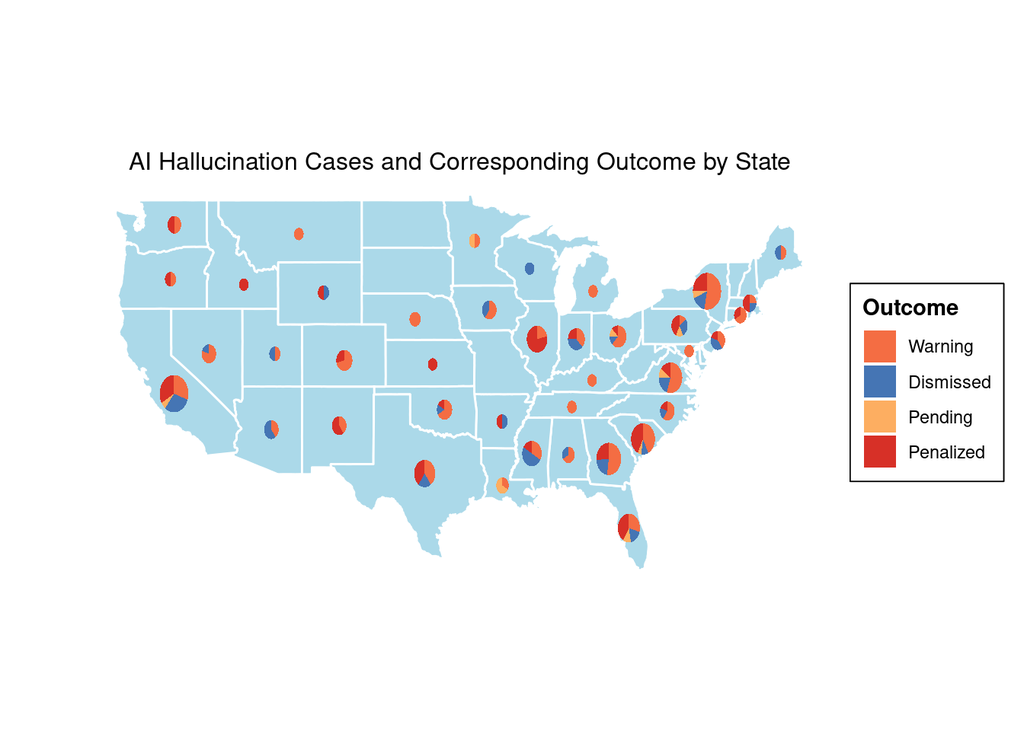

```r
ggplot() +
  geom_polygon(
    data = us_map,
    aes(x = long, y = lat, group = group),
    fill = "#ABD9E9FF",
    color = "white"
  ) +
  scatterpie::geom_scatterpie(
    data = state_pies,
    aes(x = long, y = lat, r = radius),
    cols = pie_cols,
    color = NA
  ) +
  coord_fixed(1.3) +
  scale_fill_manual(
    name = "Outcome",
    values = okabe_ito
  ) +
  labs(
    title = "AI Hallucination Cases and Corresponding Outcome by State"
  ) +
  theme_void() +
  theme(
    legend.position = "right",
    plot.title      = element_text(hjust = 0.5, size = 12),
    plot.margin = margin(t = 5, r = 10, b = 5, l = 40),
    legend.background     = element_rect(fill = "white", colour = "black", size = 0.3),
    legend.box.background = element_rect(fill = "white", colour = "black", size = 0.3),
    legend.key            = element_rect(fill = "white", colour = "white"),
    legend.margin         = margin(6, 6, 6, 6),
    legend.title          = element_text(face = "bold")
  )
```

```r
ggsave("CasesbyOutcome.png", width = 6, height = 4, units = "in")
```

### Plot 3: Top 5 Hallucination Types by Outcome

#### Plot 3 Data Cleanup

##### Step 1:

```r
ai_data <- ai_data |>
  mutate(
    hallucination = case_when(
      str_detect(coalesce(hallucination, ""), regex("Miscited|Case Cited|citation|Cittions", ignore_case = TRUE)) ~ "Fake Citation",
      str_detect(coalesce(hallucination, ""), regex("Chatgpt-Generated|Irrelevant Info|Paragraph|argument|Authority",  ignore_case = TRUE)) ~ "Fake Argument",
      str_detect(coalesce(hallucination, ""), regex("Inaccuracies|Quotation|Quotations|References|quote|source|evidentiary|evidence", ignore_case = TRUE)) ~ "Fake Source/Quote",
      str_detect(coalesce(hallucination, ""), regex("Non-Existent Legal|Wrong Legal|Caselaw|case law", ignore_case = TRUE)) ~ "Fabricated Case Law",
      str_detect(coalesce(hallucination, ""), regex("norm", ignore_case = TRUE)) ~ "Fabricated Norm",
      str_detect(coalesce(hallucination, ""), regex("Fake/Incorrect|Nonexistent Cases|Non-Existent Israeli|Irrelevant Cases|Fake Legal Case|Fictitious Cases|Non-Existent Case|Or Misrepresented Cases|Non-Existent Cases|Fabricated Cases|Fake Cases|Fake Case|Fake/Flawed Cases|Fictitious Court", ignore_case = TRUE)) ~ "Fabricated Case",
      str_detect(coalesce(hallucination, ""), regex("Misrepresented Facts|Precedent", ignore_case = TRUE)) ~ "Misrepresented Fact / Precedent",
      str_detect(coalesce(hallucination, ""), regex("Legal Authorities|Fictitious Authorities|Tribunal|Outdated Advice|Fictitious Legal|Court Decisions|Misattributed Court Decisions|Fictitious Court|Fictitious Judgement|Legal Judgments|Judgements", ignore_case = TRUE)) ~ "False Legal Judgments",
      str_detect(coalesce(hallucination, ""), regex("Suspicious|Unverifiable|Allegations|Pseudolegal|None", ignore_case = TRUE)) ~ "Unable to Conclude AI-Generated Content",
      str_detect(coalesce(hallucination, ""), regex("Fabricated Attribution", ignore_case = TRUE)) ~ "Fabricated Attribution",
      str_detect(coalesce(hallucination, ""), regex("Appeal", ignore_case = TRUE)) ~ "Fake Appeal Brief",
      TRUE ~ hallucination
    )
  )
```

##### Step 2:

Finally, we converted all empty cells to NA for the standardized outcome variable, then identified the five most common hallucination types. We calculated the top hallucinations by frequency and filtered the data to include only those categories with valid outcomes. We then counted how often each outcome occurred for each hallucination type and calculated both totals and percentages within each outcome group.

```r
ai_data <- ai_data |>
  mutate(
    outcome = str_squish(outcome),
    outcome = na_if(outcome, "NA"),
    outcome = na_if(outcome, "N/A"),
    outcome = na_if(outcome, "None"),
    outcome = na_if(outcome, "")
  )

top5_hallucinations <- ai_data |>
  filter(!is.na(hallucination)) |>
  count(hallucination, sort = TRUE) |>
  distinct(hallucination, .keep_all = TRUE) |>
  slice_head(n = 5) |>
  pull(hallucination) |>
  unique()


hall_outcome <- ai_data |>
  filter(
    hallucination %in% top5_hallucinations,
    !is.na(outcome)
  ) |>
  droplevels() |>
  count(outcome, hallucination, name = "n_cases") |>
  group_by(outcome) |>
  mutate(
    pct_within_outcome = n_cases / sum(n_cases),
    total_cases        = sum(n_cases)
  ) |>
  ungroup() |>
  mutate(
    hallucination = factor(hallucination,
                           levels = unique(top5_hallucinations))
  )
```

### Final Plot 3

We created a bubble plot to compare hallucination types against case outcomes. To order the x-axis meaningfully, we used fct_reorder() to sort outcomes by their total number of cases, ensuring the most common outcomes appear last. Each bubble represents a hallucination type–outcome pair, with its size showing how often that pairing occurs. Filled points with black outlines provided sharper contrast, and bubble sizes were set for distinct visibility. We applied a viridis color scale for accessibility, clearly labeled the axes for readability. Finally, we used a minimal theme and removed minor gridlines to highlight the data patterns.

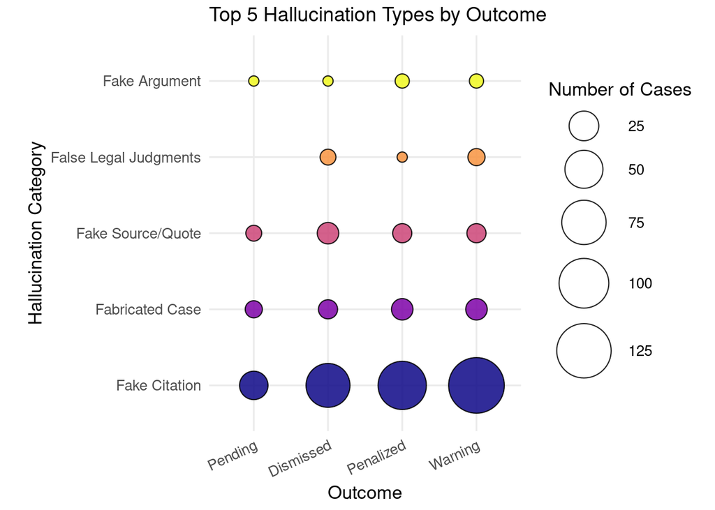

```r
ggplot(hall_outcome,
       aes(x = fct_reorder(outcome, total_cases),
           y = hallucination,
           size = n_cases,
           fill = hallucination)) +
  geom_point(shape = 21, color = "black", alpha = 0.85) +
  scale_size(range = c(3, 18), name = "Number of Cases") +
  scale_fill_viridis_d(option = "C", guide = "none") +
  labs(
    title = "Top 5 Hallucination Types by Outcome",
    x = "Outcome",
    y = "Hallucination Category"
  ) +
  theme_minimal(base_size = 13) +
  theme(
    panel.grid.minor = element_blank(),
    axis.text.x = element_text(angle = 25, hjust = 1),
    plot.title = element_text(hjust = 0, size = 14),
    plot.margin = margin(t = 5, r = 10, b = 5, l = 20)
  )
```

```r
ggsave("HallucinationybyOutcome.png", width = 6, height = 4, units = "in")
```